# Oravecz & Muth (2017). Fitting growth curve models in the Bayesian framework. Psychonomic Bulletin and Review

## Create Summary Table of posterior distributions

We use the functions provided in the papers git repository to create a summary of the posterior distribution.

- mean
- posterior standard deviation (PSD), uncertainty around the mean (similar to SE)
- posterior credibility interval (PCI), central 95% of posterior distribution
- Highest density interval (HDI), 95% range of the distribution with highest probability density
- Percentage of post. distr. below, in, or above region of practical equivalence (ROPE), here: ROPE=[-0.05,0.05], i.e. practically equivalent to zero

```r
source("posteriorSummaryStats.R")
resultTable <- summarizePost(codaSamples) %>%
  as.data.frame() %>%
  rownames_to_column("parameter")
# finds non-converged chains
resultTable %>% filter(RHAT > 1.1)
```

| parameter | mean | PSD | PCI 2.50% | PCI 97.50% | 95% HDI_Low | 95% HDI_High | st -0.05 | (-0.05,0.05) | lt 0.05 | ESS | RHAT |
| --- | --- | --- | --- | --- | --- | --- | --- | --- | --- | --- | --- |

```r
# Display summary statistics for selected parameters
resultTable %>% filter(!str_detect(parameter, "^betas"))
```

| parameter | mean | PSD | PCI 2.50% | PCI 97.50% | 95% HDI_Low | 95% HDI_High | st -0.05 | (-0.05,0.05) | lt 0.05 | ESS | RHAT |
| --- | --- | --- | --- | --- | --- | --- | --- | --- | --- | --- | --- |
| betaHighPInt | 2.0676 | 1.7663 | -1.4169 | 5.5237 | -1.5061 | 5.4193 | 0.1148 | 0.0120 | 0.8732 | 16670 | 1.0001 |
| betaHighPSlope | 0.0514 | 0.0536 | -0.0549 | 0.1568 | -0.0529 | 0.1587 | 0.0310 | 0.4559 | 0.5131 | 7112 | 1.0008 |
| betaLowPInt | -2.9379 | 1.7525 | -6.3169 | 0.5253 | -6.3496 | 0.4853 | 0.9495 | 0.0056 | 0.0449 | 14142 | 1.0002 |
| betaLowPSlope | -0.1198 | 0.0530 | -0.2243 | -0.0156 | -0.2243 | -0.0156 | 0.9055 | 0.0936 | 0.0009 | 6659 | 1.0003 |
| c_highLowPInt | 5.0055 | 1.8139 | 1.4500 | 8.5413 | 1.5392 | 8.6225 | 0.0035 | 0.0006 | 0.9959 | 25826 | 1.0001 |
| c_highLowPSlope | 0.1711 | 0.0551 | 0.0630 | 0.2791 | 0.0586 | 0.2742 | 0.0001 | 0.0131 | 0.9868 | 10315 | 1.0005 |
| c_highMedPInt | 2.0676 | 1.7663 | -1.4169 | 5.5237 | -1.5061 | 5.4193 | 0.1148 | 0.0120 | 0.8732 | 16670 | 1.0001 |
| c_highMedPSlope | 0.0514 | 0.0536 | -0.0549 | 0.1568 | -0.0529 | 0.1587 | 0.0310 | 0.4559 | 0.5131 | 7112 | 1.0008 |
| c_medLowPInt | 2.9379 | 1.7525 | -0.5253 | 6.3169 | -0.4853 | 6.3496 | 0.0449 | 0.0056 | 0.9495 | 14142 | 1.0002 |
| c_medLowPSlope | 0.1198 | 0.0530 | 0.0156 | 0.2243 | 0.0156 | 0.2243 | 0.0009 | 0.0936 | 0.9055 | 6659 | 1.0003 |

[output cut: 10 more lines]

## Make pretty output table for presentation (Optional)

*Note:* requires the stargazer package

```r
resultTable %>%
  filter(!str_detect(parameter, "^betas")) %>%
  select(-ESS, -RHAT) %>%
  rename(stROPE = `st -0.05`,
         inROPE = ` (-0.05,0.05)`,
         ltROPE = `lt 0.05`) %>%
  stargazer::stargazer(type = "text", summary = F, rownames=F)
```

```
===============================================================================================
parameter        mean   PSD  PCI 2.50% PCI 97.50% 95% HDI_Low 95% HDI_High stROPE inROPE ltROPE
-----------------------------------------------------------------------------------------------
betaHighPInt    2.068  1.766  -1.417     5.524      -1.506       5.419     0.115  0.012  0.873
betaHighPSlope  0.051  0.054  -0.055     0.157      -0.053       0.159     0.031  0.456  0.513
betaLowPInt     -2.938 1.752  -6.317     0.525      -6.350       0.485     0.950  0.006  0.045
betaLowPSlope   -0.120 0.053  -0.224     -0.016     -0.224       -0.016    0.906  0.094  0.001
c_highLowPInt   5.005  1.814   1.450     8.541       1.539       8.623     0.004  0.001  0.996
c_highLowPSlope 0.171  0.055   0.063     0.279       0.059       0.274     0.0001 0.013  0.987
c_highMedPInt   2.068  1.766  -1.417     5.524      -1.506       5.419     0.115  0.012  0.873
c_highMedPSlope 0.051  0.054  -0.055     0.157      -0.053       0.159     0.031  0.456  0.513
c_medLowPInt    2.938  1.752  -0.525     6.317      -0.485       6.350     0.045  0.006  0.950
c_medLowPSlope  0.120  0.053   0.016     0.224       0.016       0.224     0.001  0.094  0.906
corrIntSlope    0.240  0.259  -0.196     0.841      -0.215       0.808     0.117  0.124  0.759
highPInt        77.346 1.294  74.800     79.857     74.778       79.829      0      0      1
highPSlope      -0.032 0.039  -0.110     0.045      -0.108       0.047     0.318  0.663  0.019
lowPInt         72.341 1.271  69.841     74.817     69.811       74.783      0      0      1
lowPSlope       -0.203 0.038  -0.278     -0.128     -0.279       -0.128      1      0      0
medPInt         75.279 1.223  72.833     77.656     72.938       77.743      0      0      1
medPSlope       -0.083 0.037  -0.156     -0.010     -0.156       -0.010    0.816  0.184  0.0003
sdIntercept     6.710  0.618   5.590     8.001       5.542       7.942       0      0      1
sdLevel1Error   5.702  0.284   5.177     6.280       5.169       6.269       0      0      1
sdSlope         0.121  0.037   0.040     0.187       0.041       0.187       0    0.043  0.957
-----------------------------------------------------------------------------------------------
```

## Alternative solution to get posterior summary

The paper uses a pretty complex script to produce the summary table. It’s probably possible to create the same table with less code. I’ve tried but couldn’t figure out (yet) how to get the same values for ESS and RHAT, and how to get ROPE-related statistics.

*Not functional*

```r
to_df <- function(x) rownames_to_column(as.data.frame(x), "parameter")

s <-summary(codaSamples, quantiles=c(0.025, 0.975))  # quantiles = Credible intervals (here 95% interval)
s1 <- to_df(s[[1]])
s2 <- to_df(s[[2]])
s3 <- to_df(HDInterval::hdi(codaSamples, credMass = 0.95) %>% t())   # produces 0.95 HDI
s4 <- to_df(effectiveSize(codaSamples)) %>% rename(ESS = x) # Effective Sample Size (ESS)
s5 <- to_df(gelman.diag(codaSamples, multivariate = F)$psrf) # R hat convergence diagnostic

myResultTable <- full_join(s1, s2, by = "parameter") %>%
                 full_join(s3, by = "parameter") %>%
                 full_join(s4, by = "parameter") %>%
                 full_join(s5, by = "parameter") %>%
                 select(-`Naive SE`, -`Time-series SE`, -`Upper C.I.`) %>%
                 rename(mean = Mean,
                       PSD = SD,
                       PCI_low = `2.5%`,
                       PCI_high = `97.5%`,
                       HDI_low = lower,
                       HDI_high = upper,
                       RHAT = `Point est.`)

myResultTable %>% filter(!str_detect(parameter, "^betas"))
```

## Model Summary

```r
# Get individual intercepts and slopes
betas <- resultTable %>%
  filter(str_detect(parameter, "betas")) %>%
  extract(parameter, c("subject", "coef"), "betas\\[([0-9]+),([0-9]+)\\]") %>%
  mutate(subject = as.factor(subject),
         coef = recode(coef, "1" = "intercept", "2" = "slope")) %>%
  select(subject, coef, mean) %>%
  spread(key = coef, value = mean)
betas
```

|  | subject | intercept | slope |
| --- | --- | --- | --- |
| 1 | 1 | 77.3587 | -0.0580 |
| 2 | 10 | 75.4100 | -0.0546 |
| 3 | 100 | 75.2399 | -0.1508 |
| 4 | 101 | 70.1863 | -0.3891 |
| 5 | 102 | 82.1547 | -0.0305 |
| 6 | 103 | 74.5566 | -0.0781 |
| 7 | 104 | 70.9505 | -0.0770 |
| 8 | 105 | 59.4978 | -0.2567 |
| 9 | 106 | 83.5585 | 0.0024 |
| 10 | 107 | 80.4842 | -0.1509 |

[output cut: 98 more lines]

```r
# make predictions for individuals
predictions <- loveData %>%
  left_join(betas, by = "subject") %>%
  mutate(predicted = intercept + month*slope)
```

```
Column `subject` joining factors with different levels, coercing to character vector
```

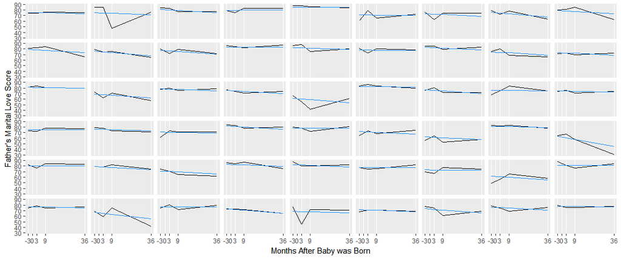

```r
# select subsample of subjects for plot
s <- sample(unique(loveData$subject), 54)
predictions %>%
  filter(subject %in% s) %>%
  ggplot(aes(month, score, group = subject)) +
    geom_line(aes(), show.legend = F) +   # Observed
    geom_line(aes(y = predicted), col = "dodgerblue", show.legend = F) +  # Predicted
    facet_wrap(~subject, nrow=6) +
    scale_x_continuous(name = "Months After Baby was Born", breaks = c(-3, 0, 3, 9, 36)) +
    scale_y_continuous(name = "Father's Marital Love Score") +
    theme(strip.background = element_blank(),
          strip.text.x = element_blank())
```

```r
ggsave("observed_predicted_individual.png", width=12, height=5)
```

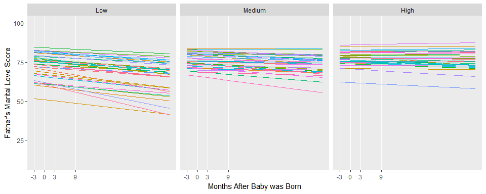

```r
predictions %>%
  ggplot(aes(month, predicted, group = subject)) +
    geom_line(aes(col = subject), show.legend = F) +
    facet_grid(~posFactor) +
    scale_x_continuous(name = "Months After Baby was Born", breaks = c(-3, 0, 3, 9, 39)) +
    scale_y_continuous(name = "Father's Marital Love Score", limits = c(10,100))
```

```r
ggsave("predicted.png", width = 10, height = 4)
```

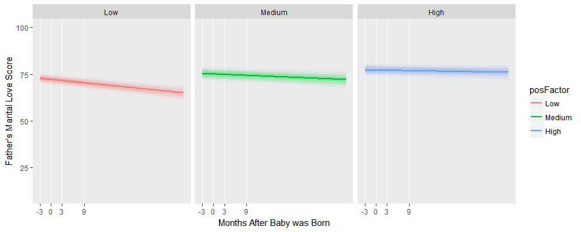

```r
# get a subset of the parameter samples
low <- data.frame(int = unlist(codaSamples[,"lowPInt"])[seq(1,30000,50)],
                  slope = unlist(codaSamples[,"lowPSlope"])[seq(1,30000,50)])
med <- data.frame(int = unlist(codaSamples[,"medPInt"])[seq(1,30000,50)],
                  slope = unlist(codaSamples[,"medPSlope"])[seq(1,30000,50)])
high <- data.frame(int = unlist(codaSamples[,"highPInt"])[seq(1,30000,50)],
                   slope = unlist(codaSamples[,"highPSlope"])[seq(1,30000,50)])
samplesFromChains <- bind_rows("Low" = low, "Medium" = med, "High" = high, .id = "posFactor")
samplesFromChains <- samplesFromChains %>%
  mutate(id = row_number(),
         t1 = int - 3 * slope,
         t2 = int + 36 * slope,
         posFactor = ordered(posFactor, levels = c("Low", "Medium", "High"))) %>%
  gather(month, score, t1:t2) %>%
  mutate(month = recode(month, "t1"=-3, "t2"=36))
# get the mean intercept and slope for each postitivity group
means <- resultTable %>%
  filter(str_detect(parameter, "^(high|med|low)P(Int|Slope)")) %>%
  transmute(posFactor = str_extract(parameter, "(low|med|high)"),
            parameter = str_extract(parameter, "(Int|Slope)") %>% str_to_lower(),
            mean = mean) %>%
  spread(parameter, mean) %>%
  mutate(id = row_number(),
         t1 = int - 3 * slope,
         t2 = int + 36 * slope,
         posFactor = recode_factor(posFactor,
           low = "Low", med = "Medium", high = "High", .ordered = T)) %>%
  gather(month, score, t1:t2) %>%
  mutate(month = recode(month, "t1"=-3, "t2"=36))
# plot
samplesFromChains %>%
  ggplot(aes(x = month, y = score, group = id, color = posFactor)) +
  geom_line(alpha = .01) +
  geom_line(data = means, size = 1) +
  facet_wrap(~ posFactor) +
  scale_x_continuous(name = "Months After Baby was Born", breaks = c(-3, 0, 3, 9, 39)) +
  scale_y_continuous(name = "Father's Marital Love Score", limits = c(10,100))
```

```r
ggsave("predicted_mean.png", width = 10, height = 4)
```

## Calculate DIC

Deviance Information Criterion quantifies how well the model reduces uncertainty in future predictions and can be used to compare models in terms of their relative goodness of fit. It accounts for model complexity and model fit. Lower DIC = better model performance in predicting future values.

- DIC>5: some difference,
- DIC>10: considerable difference.

```r
dicSamples <- dic.samples(mdl, nIter, thin = thinning, "pD", progress.bar = "gui")
show(dicSamples)
```

```
Mean deviance:  2727
penalty 129.2
Penalized deviance: 2856
```

## Fit the same (?) model with stan + brms

There are some packages that try to make fitting bayesian models easier. One of them is brms. Note that this uses [Stan](https://github.com/stan-dev/rstan/wiki/RStan-Getting-Started) instead of jags, so you will have to install Stan first.

```r
library(brms)   # requires rstan
fit <- brm(score ~ posFactor*month + (1 + month|subject),
           data = loveData,
           prior = c(
             set_prior("normal(0,100)", class = "Intercept"),
             set_prior("normal(0,100)", class = "b"),
             set_prior("uniform(0,100)", class = "sd"),
             set_prior("uniform(0,100)", class = "sd", group = "subject")
           ),
           warmup = 1000, iter = nIter, chains = 6, thin = thinning)
```

```
It appears as if you have specified an upper bounded prior on a parameter that has no natural upper bound.
If this is really what you want, please specify argument 'ub' of 'set_prior' appropriately.
Warning occurred for prior
sd ~ uniform(0,100)
sd_subject ~ uniform(0,100)
```

[output not shown]

[output cut: 86 more lines]

[output not shown]

```r
# Note: There is a warning message about the boundaries for the uniform priors not being set.
# However, setting them, via set_prior("uniform(0,100)", lb = 0, ub = 100, class = "sd"), creates
# an Error, indicating that setting boundaries is not possible in this case. The model seems to
# run fine without the boundaries, sespite the error message.
```

```r
summary(fit)
```

```
 Family: gaussian(identity)
Formula: score ~ posFactor * month + (1 + month | subject)
   Data: loveData (Number of observations: 432)
Samples: 6 chains, each with iter = 25000; warmup = 1000; thin = 5;
         total post-warmup samples = 28800
    ICs: LOO = Not computed; WAIC = Not computed

Group-Level Effects:
~subject (Number of levels: 108)
                     Estimate Est.Error l-95% CI u-95% CI Eff.Sample Rhat
sd(Intercept)            6.68      0.61     5.56     7.94      22416    1
sd(month)                0.12      0.04     0.04     0.19      11878    1
cor(Intercept,month)     0.23      0.25    -0.20     0.82      16768    1

Population-Level Effects:
                 Estimate Est.Error l-95% CI u-95% CI Eff.Sample Rhat
Intercept           76.44      1.23    74.04    78.87      21241    1
posFactor1          -4.14      1.75    -7.57    -0.69      21099    1
posFactor3           0.96      1.79    -2.53     4.44      21372    1
month               -0.09      0.04    -0.16    -0.02      27497    1
posFactor1:month    -0.11      0.05    -0.22    -0.01      28111    1
posFactor3:month     0.06      0.05    -0.05     0.17      28164    1

Family Specific Parameters:
      Estimate Est.Error l-95% CI u-95% CI Eff.Sample Rhat
sigma     5.69      0.28     5.16     6.27      17107    1

Samples were drawn using sampling(NUTS). For each parameter, Eff.Sample
is a crude measure of effective sample size, and Rhat is the potential
scale reduction factor on split chains (at convergence, Rhat = 1).
```

```r
# use plot() for graphical convergence diagnostics
# plot(fit)
# use launch_shiny() for an interactive app for model exploration
# launch_shiny(fit)
predictions <- loveData %>%
  mutate(predicted = predict(fit)[,"Estimate"])
```

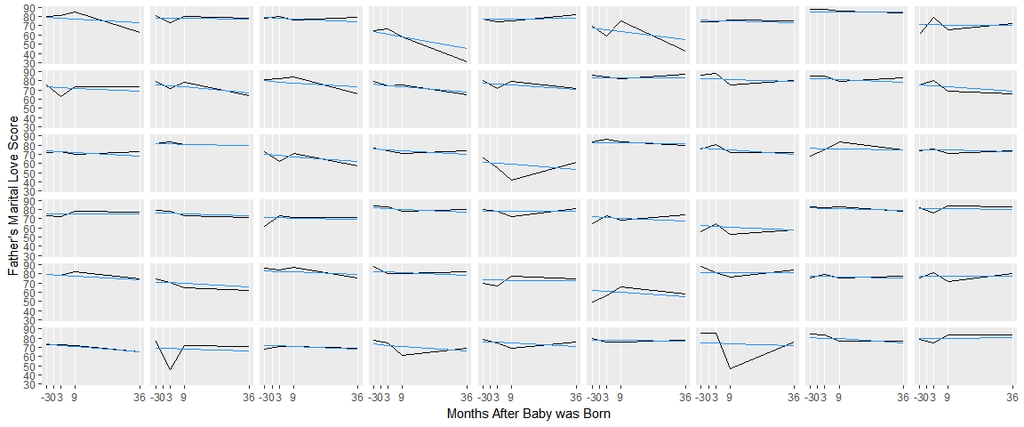

```r
# plot subsample of subjects
# (commentet out, so same sample as above is used)
# s <- sample(unique(loveData$subject), 49)
filter(predictions, subject %in% s) %>%
  ggplot(aes(month, score, group = subject)) +
    geom_line(aes(), show.legend = F) +   # Observed
    geom_line(aes(y = predicted), col = "dodgerblue", show.legend = F) +
    facet_wrap(~subject, nrow=6) +
    scale_x_continuous(name = "Months After Baby was Born", breaks = c(-3, 0, 3, 9, 36)) +
    scale_y_continuous(name = "Father's Marital Love Score") +
    theme(strip.background = element_blank(),
          strip.text.x = element_blank())
```

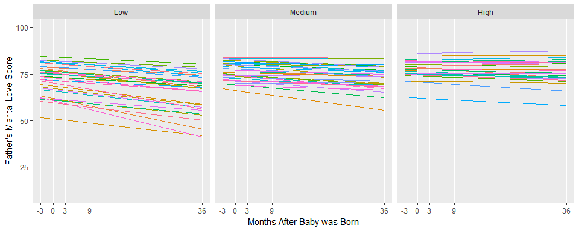

```r
predictions %>%
  ggplot(aes(month, predicted, group = subject)) +
    geom_line(aes(col = subject), show.legend = F) +
    facet_grid(~posFactor) +
    scale_x_continuous(name = "Months After Baby was Born", breaks = c(-3, 0, 3, 9, 36)) +
    scale_y_continuous(name = "Father's Marital Love Score", limits = c(10,100))
```

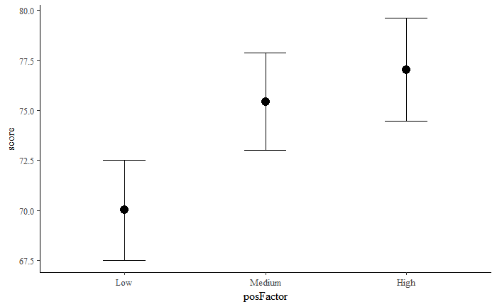

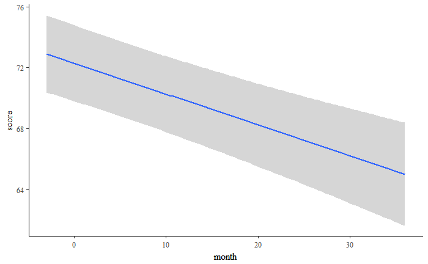

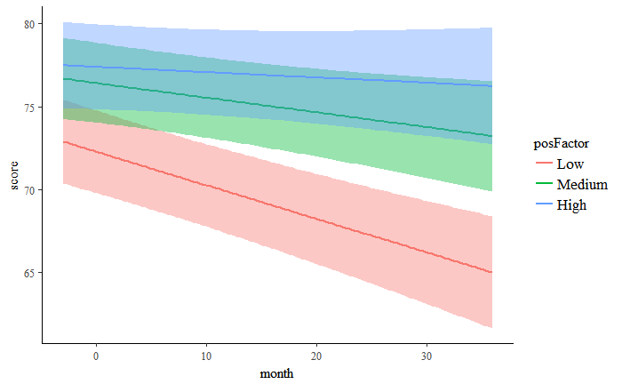

```r
marginal_effects(fit)
```

## As a comparison, run the same (?) model with lme4 (i.e. non-Bayesian)

```r
library(lme4)
lmerfit <- lmer(score ~ posFactor*month + (1 + month|subject), data = loveData)
summary(lmerfit)
```

```
Linear mixed model fit by REML ['lmerMod']
Formula: score ~ posFactor * month + (1 + month | subject)
   Data: loveData

REML criterion at convergence: 2969.4

Scaled residuals:
    Min      1Q  Median      3Q     Max
-4.8044 -0.3856  0.1232  0.5085  2.8923

Random effects:
 Groups   Name        Variance Std.Dev. Corr
 subject  (Intercept) 43.52072 6.5970
          month        0.01813 0.1346   0.16
 Residual             31.28396 5.5932
Number of obs: 432, groups:  subject, 108

Fixed effects:
                 Estimate Std. Error t value
(Intercept)      76.44237    1.21175   63.08
posFactor1       -4.14842    1.73731   -2.39
posFactor3        0.95264    1.76335    0.54
month            -0.08903    0.03746   -2.38
posFactor1:month -0.11364    0.05371   -2.12
posFactor3:month  0.05719    0.05452    1.05

Correlation of Fixed Effects:
            (Intr) psFct1 psFct3 month  psFc1:
posFactor1  -0.697
posFactor3  -0.687  0.479
month       -0.147  0.103  0.101
psFctr1:mnt  0.103 -0.147 -0.070 -0.697
psFctr3:mnt  0.101 -0.070 -0.147 -0.687  0.479
```